| title Fejlanalyse |
| --- |
| author Maltheren |
| date 2024-11-25 |
| output html_document |

## En hurtig kigger på hvad vi kan se med vores data

```r
distancetest = read.csv("distance_data.csv",header = TRUE)
```

Alle målingerne med de dårlige og det hele er blevet loadet som 2 kolonner i en csv fil som ser sådan her ud.

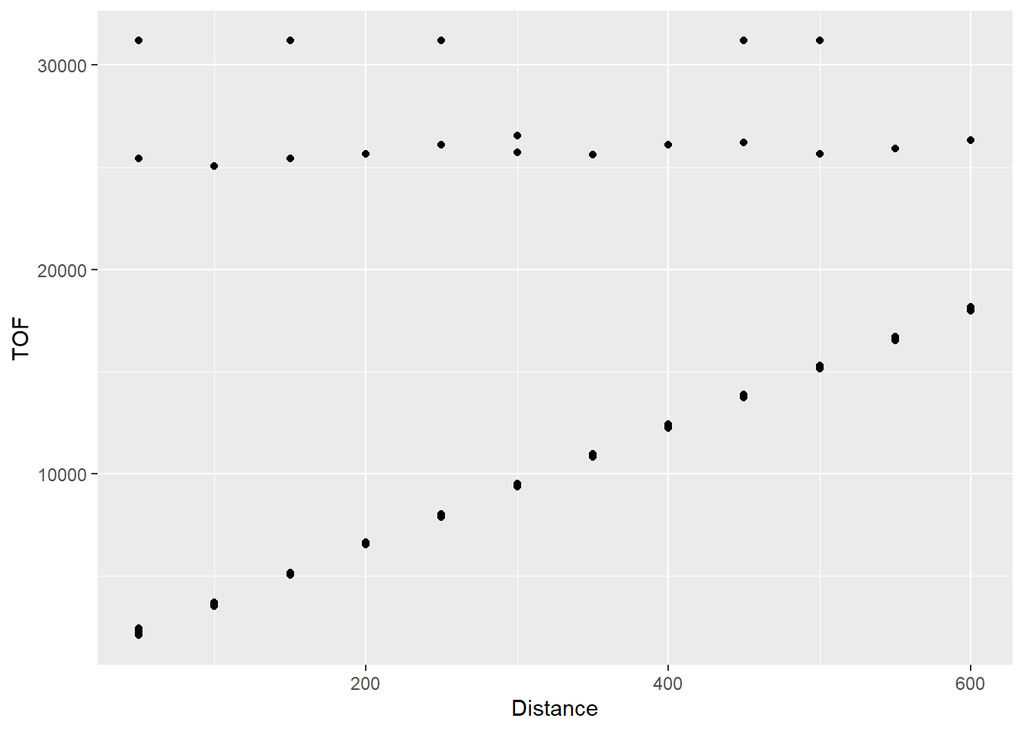

Det ligner bare lidt lort tho :((.

Men ved at lave et boksplot over fordelingen ved en given afstand:

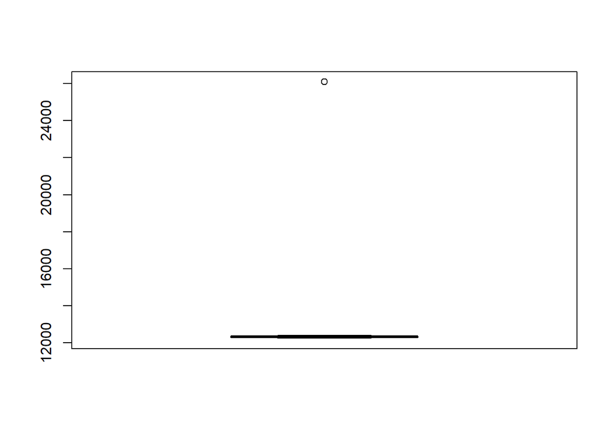

```r
filter_outliers <- function(data){
  qnt <- quantile(data, probs=c(.25, .75), na.rm = T)
  iqr <- IQR(data)
  lower <- qnt[1] - 15*iqr
  upper <- qnt[2] + 15*iqr
  data <- data[data > lower & data < upper]
  return(data)

}
```

Så kan alle målte længder fås ved at køre den her

```r
distances = unique(distancetest$Distance)
print(sort(distances))
```

```
##  [1]  50 100 150 200 250 300 350 400 450 500 550 600
```

Så kører vi filteret på alle de her afstande datasættet

```r
for (distance in distances){
  values_read = distancetest$TOF[distancetest$Distance==distance]; ##Læser alle værdier ved en afstand
  distancetest$TOF[distancetest$Distance==distance] = filter_outliers(values_read); ##Sætter alle værdier til den afstand som det. Det lidt magi men det virker :/.
}
```

Det giver os det her :)))

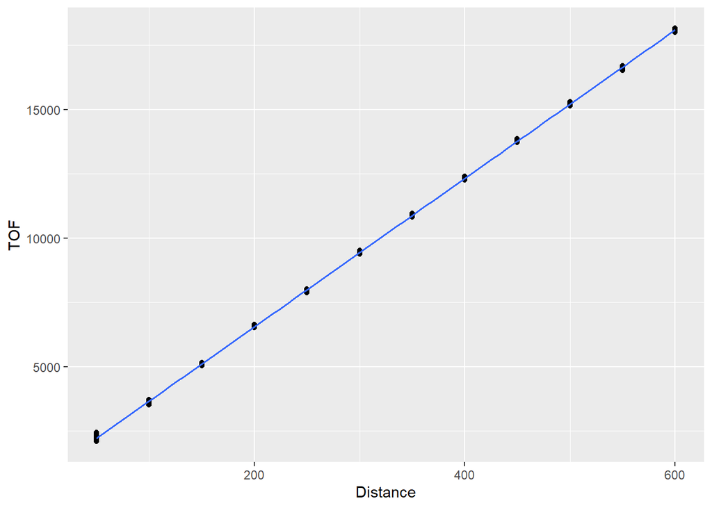

```r
gf_point(TOF ~ Distance, data=distancetest) %>%
  gf_lm()
```

Det kan lige laves en model på

```r
model1 <- lm(TOF~Distance, data=distancetest)
summary(model1)
```

```
##
## Call:
## lm(formula = TOF ~ Distance, data = distancetest)
##
## Residuals:
##      Min       1Q   Median       3Q      Max
## -148.886  -31.481    2.948   35.163  223.710
##
## Coefficients:
##              Estimate Std. Error t value Pr(>|t|)
## (Intercept) 783.69528    3.91770     200   <2e-16 ***
## Distance     28.85190    0.01064    2710   <2e-16 ***
## ---
## Signif. codes:  0 '***' 0.001 '**' 0.01 '*' 0.05 '.' 0.1 ' ' 1
##
## Residual standard error: 51.17 on 774 degrees of freedom
## Multiple R-squared:  0.9999, Adjusted R-squared:  0.9999
## F-statistic: 7.346e+06 on 1 and 774 DF,  p-value: < 2.2e-16
```

Så vi kan trække fra og så har vi kalibreret det wuhuu. Derudover kan vi trække det som vi mener lydens hastighed skal rejse med fra og se om at TOF værdien faktisk stiger med lydens hastighed

```r
v_sound = 0.01/343 * 10^6; ## Så det er så langt lyden tager om at nå 1 cm og så konverteret til us.


model1 <- lm(TOF~Distance+ offset(v_sound * Distance), data=distancetest)
summary(model1)
```

```
##
## Call:
## lm(formula = TOF ~ Distance + offset(v_sound * Distance), data = distancetest)
##
## Residuals:
##      Min       1Q   Median       3Q      Max
## -148.886  -31.481    2.948   35.163  223.710
##
## Coefficients:
##              Estimate Std. Error t value Pr(>|t|)
## (Intercept) 783.69528    3.91770  200.04   <2e-16 ***
## Distance     -0.30262    0.01064  -28.43   <2e-16 ***
## ---
## Signif. codes:  0 '***' 0.001 '**' 0.01 '*' 0.05 '.' 0.1 ' ' 1
##
## Residual standard error: 51.17 on 774 degrees of freedom
## Multiple R-squared:  0.5108, Adjusted R-squared:  0.5102
## F-statistic: 808.2 on 1 and 774 DF,  p-value: < 2.2e-16
```

Ellers er det spændednde nok at vi kan lave et histogram over residualerne og på den måde få hvor maksimale præcision vi ikke kan kalibrere os ud af.

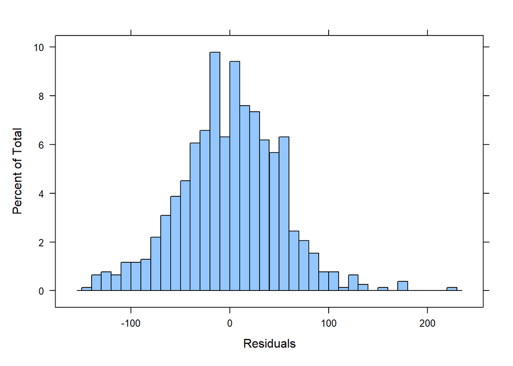

```r
histogram(model1$residuals, breaks=40, xlab="Residuals")
```

```r
favstats(model1$residuals)
```

```
##        min        Q1   median       Q3      max         mean       sd   n
##  -148.8856 -31.48069 2.948494 35.16309 223.7096 1.579683e-16 51.14047 776
##  missing
##        0
```